# Теоретическая справка

Ликвидность — свойство активов быть быстро проданными по цене, близкой к рыночной. Существует много способов посчитать ликвидность, но тем не менее нет какого-то одного общепринятого

## Объем торгов

1.1) Абсолютный объем торгов в в штуках (за определенный интервал времени)

$Q_T = \sum\limits_{t \in T}q_t$

где $q_t$ - количество актива в сделке в момент времени $t$ в штуках, $T$ - период расчета (обычно один торговый день)

1.2) Относительный объем торгов в штуках (за определенный интервал времени)

$\widehat{Q}_T = \frac{Q_T}{fn}$

где $n$ - количество акций, $f$ - коэффициент free-float

2.1) Абсолютный объем торгов в деньгах (за определенный интервал времени)

$V_T = \sum\limits_{t \in T}q_tp_t$

где $q_t$ - количество актива в сделке в момент времени $t$ в штуках, $p_t$ - цена актива в сделке в момент времени $t$, $T$ - период расчета (обычно один торговый день)

2.2) Относительный объем торгов в деньгах (за определенный интервал времени)

$\widehat{V}_T = \frac{V_T}{C_T}$

где $C_T = p_Tfn$ - рыночная капитализация на конец периода $T$, $p_T$ - цена актива на момент времени $T$, $n$ - количество акций в обращении, $f$ - коэффициент free-float

## Глубина рынка для актива

3.1) Глубина рынка для актива в штуках (bid и ask) (на определенный момент времени)

$D_\tau^{bid} = \sum\limits_{i}s_{i,\tau}^{bid}, \qquad D_\tau^{ask} = \sum\limits_{i}s_{i,\tau}^{ask}$

где $s_{i,\tau}^{bid}$ - количество актива в $i$-ой лимитированной заявке на покупку на момент $\tau$ в штуках, $s_{i,\tau}^{ask}$ - количество актива в $i$-ой лимитированной заявке на продажу на момент $\tau$ в штуках

3.2) Совокупная глубинка в штуках (на определенный момент времени)

$D_\tau = D_\tau^{bid} + D_\tau^{ask}$

3.3) Средняя глубина в штуках (на определенный момент времени)

$\overline{D}_\tau = \frac{D_\tau}{2}$

4.1) Глубина рынка для актива в деньгах (bid и ask) (на определенный момент времени) (P.S. оставим те же обозначения, чтобы не нагромождать формулы, а какую из них применять зачастую понятно из контекста или это оговаривается заранее)

$D_\tau^{bid} = \sum\limits_{i}s_{i,\tau}^{bid}p_{i,\tau}^{bid}, \qquad D_\tau^{ask} = \sum\limits_{i}s_{i,\tau}^{ask}p_{i,\tau}^{ask}$

где $p_{i,\tau}^{bid}$ - цена актива в $i$-ой лимитированной заявке на покупку на момент $\tau$, $p_{i,\tau}^{ask}$ - цена актива в $i$-ой лимитированной заявке на продажу на момент $\tau$

4.2) Совокупная глубина в деньгах (на определенный момент времени)

$D_\tau = D_\tau^{bid} + D_\tau^{ask}$

4.3) Средняя глубина в деньгах (на определенный момент времени)

$\overline{D}_\tau = \frac{D_\tau}{2}$

## Широта рынка для актива

5.1) Широта рынка для актива в штуках (bid и ask) (на определенный момент времени)

$W_\tau^{bid} = s_{\tau}^{BestBid}, \qquad W_\tau^{ask} = s_{\tau}^{BestAsk}$

где $s_{\tau}^{BestBid}$ - количество актива в лучшей лимитированной заявке на покупку на момент $\tau$ в штуках, $s_{\tau}^{BestAsk}$ - количество актива в лучшей лимитированной заявке на продажу на момент $\tau$ в штуках

5.2) Совокупная широта в штуках (на определенный момент времени)

$W_\tau = W_\tau^{bid} + W_\tau^{ask}$

5.3) Средняя широта в штуках (на определенный момент времени)

$\overline{W}_\tau = \frac{W_\tau}{2}$

6.1) Широта рынка для актива в деньгах (bid и ask) (на определенный момент времени) (P.S. оставим те же обозначения, чтобы не нагромождать формулы, а какую из них применять зачастую понятно из контекста или это оговаривается заранее)

$W_\tau^{bid} = s_{\tau}^{BestBid}p_{\tau}^{BestBid}, \qquad W_\tau^{ask} = s_{\tau}^{BestAsk}p_{\tau}^{BestAsk}$

где $p_{\tau}^{BestBid}$ - цена актива в лучшей лимитированной заявке на покупку на момент $\tau$, $p_{\tau}^{BestAsk}$ - цена актива в лучшей лимитированной заявке на продажу на момент $\tau$

6.2) Совокупная широта в деньгах (на определенный момент времени)

$W_\tau = W_\tau^{bid} + W_\tau^{ask}$

6.3) Средняя широта в деньгах (на определенный момент времени)

$\overline{W}_\tau = \frac{W_\tau}{2}$

## Спред

7.1) Абсолютный спред

$S_\tau = p_{\tau}^{BestAsk} - p_{\tau}^{BestBid}$

7.2) Относительный спред

$\widehat{S}_\tau = \frac{p_{\tau}^{BestAsk} - p_{\tau}^{BestBid}}{M_{\tau}}$

где $M_{\tau} = \frac{p_{\tau}^{BestAsk} + p_{\tau}^{BestBid}}{2}$ - средняя точка

## Количество сделок

8.1) Количество совершенных сделок (за определенный интервал времени)

$N_T = \#\{q_t: t \in T\}$

## Время ожидания

9.1) Среднее время ожидания между двумя сделками (за определенный интервал времени)

$\theta = \frac{\sum_{j \in T}(t_j - t_{j-1})}{\#\{t_j: t_j \in T\}}$

где $t_j$ - $j$-ый момент времени совершения сделки, $t_{j-1}$ - предшествующий момент совершения сделки, $T$ - период расчета (обычно один торговый день)

## Коэффициент ликвидности (принятая в методике московской биржы)

10.1) Зафиксируем период $T$ (без ограничения общности будем считать что $T$ - один день). Обозначим за $\Delta$ - бОльший период, который содержит в себе периоды, равные по "длине" $T$, то есть $\Delta = \bigcup\limits_i T_i$, причем $\mid T_i\mid = \mid T\mid \forall i$. Теперь пусть $V_{T_i}$ - абсолютный объем торгов в деньгах за период $T_i$. Тогда

$LC_\Delta = \frac{median(V_{T_i})}{\overline{C}_\Delta}WorkDays*100\%$

где $median(*)$ - медиана за промежуток $\Delta$, $\overline{C}_\Delta = \frac{\sum\limits_{T_i \in \Delta}p_{T_i}fn}{\mid \Delta \mid}$ - средняя капитализация за промежуток $\Delta$, $WorkDays$ - количество рабочих дней (по умолчанию 247)

## Наклон

11.1) Коэффициент наклона

$QS_\tau = \frac{p_{\tau}^{BestAsk} - p_{\tau}^{BestBid}}{s_{\tau}^{BestAsk} + s_{\tau}^{BestBid}}$

11.2) Коэффициент наклона в логарифмической шкале

$LOGQS_\tau = \frac{\ln{p_{\tau}^{BestAsk}} - \ln{p_{\tau}^{BestBid}}}{\ln{s_{\tau}^{BestAsk}} + \ln{s_{\tau}^{BestBid}}}$

Так как в последствии предстоит сравнивать ликвидность разных инструментов, то возьмем лишь безразмерные или относительные величины, чтобы сравнение коэффициентов было корректным. Это показатели 1.2) 2.2) 7.2) 8.1) 9.1) 11.2)

# Алгоритм расчета

```python
#подключение библиотек
import numpy as np
import pandas as pd
import datetime
from collections import namedtuple
from math import log
```

```python
# будем отображать графики прямо в jupyter'e
%matplotlib inline
import matplotlib.pyplot as plt

#увеличим дефолтный размер графиков
from pylab import rcParams
rcParams['figure.figsize'] = 16, 9
```

## Генераторы для потокового получения данных с файлов

```python
Order = namedtuple('Order', ['price', 'amount'])

#генератор, возвращающий из файла последовательно снимок книги заявок (orderbook)
def gen_read_quotes(file_path):
    inFile = open(file_path, 'r', encoding='utf8')
    #считываем первую строку с информацией и преобразуем ее
    *info, lot, price_step = inFile.readline().split(':')
    lot = int(lot) if lot else 1
    price_step = float(price_step) if price_step else None

    #создаем пустую книгу заявок
    orderbook = None

    while True:
        line = inFile.readline()
        if line.split(': ')[0] == 'Received': #если начало нового скриншота книги заявок (или по другому снимок книги заявок)
            if orderbook: #и есть предыдущий скриншот книги заявок, то возвращаем его
                yield orderbook

            time_str = line.split(': ')[1].strip()
            time = datetime.datetime.strptime(time_str, '%d.%m.%Y %H:%M:%S.%f')

            orderbook = {'Received': time, 'Bid': [], 'Ask': []} #создаем новый пустой скриншот книги заявок
        elif line != '': #иначе собираем эту книгу заявок
            try: #пытаемся распарсить строку и добавляем запись в orderbook
                deal_type, price, volume = line.strip().split(';')
                price, volume = float(price), int(volume)

                if deal_type == 'Ask' or deal_type == 'BestAsk':
                    orderbook['Ask'].append(Order(price, volume*lot))
                elif deal_type == 'Bid' or deal_type == 'BestBid':
                    orderbook['Bid'].append(Order(price, volume*lot))
                else:
                    pass
            except: #иначе пропускаем строку
                continue
        else: #если конец файла, то выходим из цикла
            break
    inFile.close()
```

```python
Deal = namedtuple('Deal', ['received', 'type', 'price', 'amount'])

#генератор, возвращающий из файла последовательно совершенные сделки (deal)
def gen_read_deals(file_path):
    inFile = open(file_path, 'r', encoding='utf8')
    #считываем первую строку с информацией и преобразуем ее
    *info, lot, price_step = inFile.readline().split(':')
    lot = int(lot) if lot else 1
    price_step = float(price_step) if price_step else None

    while True:
        line = inFile.readline()
        if line:
            try: #пытемся распарсить строку и возвращаем информацию по сделке
                received, exch_time, deal_id, deal_type, price, volume, OI = line.strip().split(';')
                received = datetime.datetime.strptime(received, '%d.%m.%Y %H:%M:%S.%f')
                price = float(price)
                amount = int(volume)*lot
                deal = Deal(received, deal_type, price, amount)
                yield deal
            except: #иначе пропускаем строку
                continue
        else: #если конец файла, то выходим из цикла
            break
    inFile.close()
```

## Генераторы для подсчета коэффициентов ликвидности по потоку данных

```python
#дополнительные данные (собирал вручную) https://www.moex.com/ru/index/IMOEX/constituents/
StockInfo = namedtuple('StockInfo', ['n', 'free_float']) #количество выпущенных акций и коэффициент free-float

Info = {'CHMF': StockInfo(837718660, 0.2),
        'MOEX': StockInfo(2276401458, 0.63),
        'NVTK': StockInfo(3036306000, 0.21),
        'RASP': StockInfo(703271727, 0.12),
        'SBER': StockInfo(21586948000, 0.48),
        'TATN': StockInfo(2178690700, 0.32),
        'YNDX': StockInfo(293527656, 0.96)}
```

```python
#все генераторы будут возвращать кортеж с информацией о дате и времени, к которому был посчитан коэффициент, и само значение
Coef = namedtuple('Coefficient', ['date', 'result'])
```

```python
#1.2) Относительный объем торгов в штуках
def relative_volume(deals_file, T, info): #T - timedelta (период), info - словарь с дополнительной информацией
    #считываем первую строку с информацией, чтобы узнать тикер
    inFile = open(deals_file, 'r', encoding='utf8')
    connection_type, ticker, share_type, lot, price_step = inFile.readline().strip().split(':')
    inFile.close()

    if ticker in info.keys(): #если дополнительных данных по данному тикеру нет, то расчетов не будет совсем
        #по данному тикеру загружаем данные по количеству акций в выпуске и коэффициенту free float
        n = info[ticker].n
        f = info[ticker].free_float

        #начало и конец торгового дня
        day_start = datetime.time(hour=10, minute=0, second=0, microsecond=0)
        day_end = datetime.time(hour=18, minute=40, second=0, microsecond=0)

        time_checkpoint = None
        Q = 0 #volume
        for deal in gen_read_deals(deals_file):
            if not time_checkpoint: #если еще не сконструирован time_checkpoint, то создаем его
                time_checkpoint = datetime.datetime.combine(deal.received.date(), day_start) + T

            if deal.received.time() < day_start or deal.received.time() > day_end: #если сделка произошла до day_start или после day_end, то пропускаем
                continue
            else:
                if deal.received < time_checkpoint: #пока не дошли до time_checpoint'a, суммируем объем торгов в штуках
                    Q += deal.amount
                else: #иначе обновляем time_checkpoint и возвращаем объем торгов
                    yield Coef(time_checkpoint, round(Q/(f*n), 8))
                    time_checkpoint = time_checkpoint + T
                    Q = 0
        else:
            last_checkpoint = datetime.datetime.combine(time_checkpoint.date(), day_end)
            yield Coef(last_checkpoint, round(Q/(f*n), 8))
```

```python
#2.2) Относительный объем торгов в деньгах
def relative_value(deals_file, T, info): #T - timedelta (период), info - словарь с дополнительной информацией
    #считываем первую строку с информацией, чтобы узнать тикер
    inFile = open(deals_file, 'r', encoding='utf8')
    connection_type, ticker, share_type, lot, price_step = inFile.readline().strip().split(':')
    inFile.close()

    if ticker in info.keys(): #если дополнительных данных по данному тикеру нет, то расчетов не будет совсем
        #по данному тикеру загружаем данные по количеству акций в выпуске и коэффициенту free float
        n = info[ticker].n
        f = info[ticker].free_float

        #начало и конец торгового дня
        day_start = datetime.time(hour=10, minute=0, second=0, microsecond=0)
        day_end = datetime.time(hour=18, minute=40, second=0, microsecond=0)

        time_checkpoint = None
        V = 0 #value
        for deal in gen_read_deals(deals_file):
            if not time_checkpoint: #если еще не сконструирован time_checkpoint, то создаем его
                time_checkpoint = datetime.datetime.combine(deal.received.date(), day_start) + T

            if deal.received.time() < day_start or deal.received.time() > day_end: #если сделка произошла до day_start или после day_end, то пропускаем
                continue
            else:
                if deal.received < time_checkpoint: #пока не дошли до time_checpoint'a, суммируем объем торгов в деньгах
                    V += deal.amount*deal.price
                    last_price = deal.price
                else: #иначе обновляем time_checkpoint и возвращаем объем торгов
                    yield Coef(time_checkpoint, round(V/(last_price*f*n), 8))
                    time_checkpoint = time_checkpoint + T
                    V = 0
                    last_price = deal.price
        else:
            last_checkpoint = datetime.datetime.combine(time_checkpoint.date(), day_end)
            yield Coef(last_checkpoint, round(V/(last_price*f*n), 8))
```

```python
#7.2) Относительный спред
#Модифицируем данный показатель. Будем рассчитывать относительный спред не в моменте
#(т.е. не для каждого скриншота orderbook), а среднее значение показателя за период T,
#чтобы динамику изменения различных показателей ликвидности можно было сравнивать еще и между собой
def relative_spread(quotes_file, T):
    #начало и конец торгового дня
    day_start = datetime.time(hour=10, minute=0, second=0, microsecond=0)
    day_end = datetime.time(hour=18, minute=40, second=0, microsecond=0)

    time_checkpoint = None
    Sspread = 0 #spreads sum
    Nspread = 0 #spreads count
    for orderbook in gen_read_quotes(quotes_file):
        if not time_checkpoint: #если еще не сконструирован time_checkpoint, то создаем его
            time_checkpoint = datetime.datetime.combine(orderbook['Received'].date(), day_start) + T

        if orderbook['Received'].time() < day_start or orderbook['Received'].time() > day_end: #если скриншот orderbook сделан до day_start или после day_end, то пропускаем
            continue
        else:
            if orderbook['Received'] < time_checkpoint: #пока не дошли до time_checpoint'a
                try: #и если данных хватает (т.е. есть данных и по биду и по аску)
                    midpoint = (orderbook['Ask'][-1].price + orderbook['Bid'][0].price)/2
                    Sspread += (orderbook['Ask'][-1].price - orderbook['Bid'][0].price)/midpoint
                    Nspread += 1
                except: #иначе пропускаем
                    continue
            else: #а если дошли до time_checpoint'a, то обновляем time_checkpoint, рассчитываем средний спред и начинаем считать Sspread и Nspread заново
                spread = Sspread/Nspread if Nspread != 0 else None
                yield Coef(time_checkpoint, round(spread, 8))
                time_checkpoint = time_checkpoint + T
                midpoint = (orderbook['Ask'][-1].price + orderbook['Bid'][0].price)/2
                Sspread = (orderbook['Ask'][-1].price - orderbook['Bid'][0].price)/midpoint
                Nspread = 1
    else:
        spread = Sspread/Nspread if Nspread != 0 else None
        last_checkpoint = datetime.datetime.combine(time_checkpoint.date(), day_end)
        yield Coef(last_checkpoint, round(spread, 8))
```

```python
#8.1) Количество совершенных сделок
def deals_count(deals_file, T): #T - timedelta (период)
    #начало и конец торгового дня
    day_start = datetime.time(hour=10, minute=0, second=0, microsecond=0)
    day_end = datetime.time(hour=18, minute=40, second=0, microsecond=0)

    time_checkpoint = None
    N = 0 #count
    for deal in gen_read_deals(deals_file):
        if not time_checkpoint: #если еще не сконструирован time_checkpoint, то создаем его
            time_checkpoint = datetime.datetime.combine(deal.received.date(), day_start) + T

        if deal.received.time() < day_start or deal.received.time() > day_end: #если сделка произошла до day_start или после day_end, то пропускаем
            continue
        else:
            if deal.received < time_checkpoint: #пока не дошли до time_checpoint'a, считаем количество сделок
                N += 1
            else: #иначе обновляем time_checkpoint возвращаем количество сделок
                yield Coef(time_checkpoint, N)
                time_checkpoint = time_checkpoint + T
                N = 0
    else:
        last_checkpoint = datetime.datetime.combine(time_checkpoint.date(), day_end)
        yield Coef(last_checkpoint, N)
```

```python
#9.1) Среднее время ожидания между двумя сделками (в секундах)
def deals_timeout(deals_file, T): #T - timedelta (период)
    #начало и конец торгового дня
    day_start = datetime.time(hour=10, minute=0, second=0, microsecond=0)
    day_end = datetime.time(hour=18, minute=40, second=0, microsecond=0)

    time_checkpoint = None
    prev_deal_time = None
    Stheta = 0 #timeouts sum
    Ntheta = 0 #timeouts count
    for deal in gen_read_deals(deals_file):
        if not time_checkpoint: #если еще не сконструирован time_checkpoint, то создаем его
            time_checkpoint = datetime.datetime.combine(deal.received.date(), day_start) + T
        if not prev_deal_time: #если еще нет данных о времени предыдущей сделки, то загружаем их как начало торгового дня
            prev_deal_time = datetime.datetime.combine(deal.received.date(), day_start)

        if deal.received.time() < day_start or deal.received.time() > day_end: #если сделка произошла до day_start или после day_end, то пропускаем
            continue
        else:
            if deal.received < time_checkpoint: #пока не дошли до time_checpoint'a, считаем сумму всех дельт
                Stheta += (deal.received - prev_deal_time).total_seconds()
                Ntheta += 1
                prev_deal_time = deal.received
            else: #иначе обновляем time_checkpoint, возвращаем среднее время ожидания и начинаем считать Stheta и Ntheta заново
                theta = Stheta/Ntheta if Ntheta != 0 else None
                yield Coef(time_checkpoint, round(theta, 8))
                time_checkpoint = time_checkpoint + T
                Stheta = (deal.received - prev_deal_time).total_seconds()
                Ntheta = 1
                prev_deal_time = deal.received
    else:
        theta = Stheta/Ntheta if Ntheta != 0 else None
        last_checkpoint = datetime.datetime.combine(time_checkpoint.date(), day_end)
        yield Coef(last_checkpoint, round(theta, 8))
```

```python
#11.2) Коэффициент наклона в логарифмической шкале
#Модифицируем данный показатель. Будем рассчитывать коэффициент наклона в логарифмической шкале не в моменте
#(т.е. не для каждого скриншота orderbook), а среднее значение показателя за период T,
#чтобы динамику изменения различных показателей ликвидности можно было сравнивать еще и между собой
def LOGQS(quotes_file, T):
    #начало и конец торгового дня
    day_start = datetime.time(hour=10, minute=0, second=0, microsecond=0)
    day_end = datetime.time(hour=18, minute=40, second=0, microsecond=0)

    time_checkpoint = None
    SLOGQS = 0 #LOGQS sum
    NLOGQS = 0 #LOGQS count
    for orderbook in gen_read_quotes(quotes_file):
        if not time_checkpoint: #если еще не сконструирован time_checkpoint, то создаем его
            time_checkpoint = datetime.datetime.combine(orderbook['Received'].date(), day_start) + T

        if orderbook['Received'].time() < day_start or orderbook['Received'].time() > day_end: #если скриншот orderbook сделан до day_start или после day_end, то пропускаем
            continue
        else:
            if orderbook['Received'] < time_checkpoint: #пока не дошли до time_checpoint'a
                try: #и если данных хватает (т.е. есть данных и по биду и по аску)
                    numerator = log(orderbook['Ask'][-1].price) - log(orderbook['Bid'][0].price)
                    denominator = log(orderbook['Ask'][-1].amount) + log(orderbook['Bid'][0].amount)
                    SLOGQS += numerator/denominator if denominator != 0 else 0
                    NLOGQS += 1
                except: #иначе пропускаем
                    continue
            else: #а если дошли до time_checpoint'a, то обновляем time_checkpoint, рассчитываем средний LOGQS и начинаем считать SLOGQS и NLOGQS заново
                LOGQS = SLOGQS/NLOGQS if NLOGQS != 0 else None
                yield Coef(time_checkpoint, round(LOGQS, 8))
                time_checkpoint = time_checkpoint + T
                numerator = log(orderbook['Ask'][-1].price) - log(orderbook['Bid'][0].price)
                denominator = log(orderbook['Ask'][-1].amount) + log(orderbook['Bid'][0].amount)
                SLOGQS = numerator/denominator if denominator != 0 else 0
                NLOGQS = 1
    else:
        LOGQS = SLOGQS/NLOGQS if NLOGQS != 0 else None
        last_checkpoint = datetime.datetime.combine(time_checkpoint.date(), day_end)
        yield Coef(last_checkpoint, round(LOGQS, 8))
```

# Расчет коэффициентов и анализ

Рассмотрим вначале каждый коэффициент ликвидности отдельно, но в разрезе компаний. Период установим в 1 час

```python
tickers = ['MOEX', 'NVTK', 'RASP', 'SBER', 'TATN', 'YNDX']
dates = ['2020-04-20', '2020-04-21', '2020-04-22', '2020-04-23', '2020-04-24']
T = datetime.timedelta(hours=1)
```

## Создание датафреймов с данными

```python
#загрузка библиотеки для скрытия ошибок, которые возникнут в будущих библиотеках
import warnings
warnings.filterwarnings("ignore")
```

```python
%%time

import warnings
warnings.filterwarnings("ignore", category=FutureWarning)

#создание dataframe по всем тикерам по всем датам для "относительный объем торгов в штуках"
list_of_series = []
for ticker in tickers:
    temp_series = pd.Series()
    for date in dates:
        file_path = '{0}\\{0}.{1}.Deals.{{1-Deals}}.txt'.format(ticker, date)
        temp_series = temp_series.append(pd.Series({coef.date: coef.result for coef in relative_volume(file_path, T, Info)}), verify_integrity=True)
    temp_series.name = ticker
    list_of_series.append(temp_series)

df_relative_volume = pd.concat(list_of_series, axis=1)
```

```
Wall time: 17.1 s
```

```python
%%time

#создание dataframe по всем тикерам по всем датам для "относительный объем торгов в деньгах"
list_of_series = []
for ticker in tickers:
    temp_series = pd.Series()
    for date in dates:
        file_path = '{0}\\{0}.{1}.Deals.{{1-Deals}}.txt'.format(ticker, date)
        temp_series = temp_series.append(pd.Series({coef.date: coef.result for coef in relative_value(file_path, T, Info)}), verify_integrity=True)
    temp_series.name = ticker
    list_of_series.append(temp_series)

df_relative_value = pd.concat(list_of_series, axis=1)
```

```
Wall time: 17 s
```

```python
%%time

#создание dataframe по всем тикерам по всем датам для "количество совершенных сделок"
list_of_series = []
for ticker in tickers:
    temp_series = pd.Series()
    for date in dates:
        file_path = '{0}\\{0}.{1}.Deals.{{1-Deals}}.txt'.format(ticker, date)
        temp_series = temp_series.append(pd.Series({coef.date: coef.result for coef in deals_count(file_path, T)}), verify_integrity=True)
    temp_series.name = ticker
    list_of_series.append(temp_series)

df_deals_count = pd.concat(list_of_series, axis=1)
```

```
Wall time: 16.8 s
```

```python
%%time

#создание dataframe по всем тикерам по всем датам для "среднее время ожидания между двумя сделками"
list_of_series = []
for ticker in tickers:
    temp_series = pd.Series()
    for date in dates:
        file_path = '{0}\\{0}.{1}.Deals.{{1-Deals}}.txt'.format(ticker, date)
        temp_series = temp_series.append(pd.Series({coef.date: coef.result for coef in deals_timeout(file_path, T)}), verify_integrity=True)
    temp_series.name = ticker
    list_of_series.append(temp_series)

df_deals_timeout = pd.concat(list_of_series, axis=1)
```

```
Wall time: 17.5 s
```

```python
%%time

#создание dataframe по всем тикерам по всем датам для "относительный спред"
list_of_series = []
for ticker in tickers:
    temp_series = pd.Series()
    for date in dates:
        file_path = '{0}\\{0}.{1}.Quotes.{{1-Quotes}}.txt'.format(ticker, date)
        temp_series = temp_series.append(pd.Series({coef.date: coef.result for coef in relative_spread(file_path, T)}), verify_integrity=True)
    temp_series.name = ticker
    list_of_series.append(temp_series)

df_relative_spread = pd.concat(list_of_series, axis=1)
```

```
Wall time: 2min 24s
```

```python
%%time

#создание dataframe по всем тикерам по всем датам для "коэффициент наклона в логарифмической шкале"
list_of_series = []
for ticker in tickers:
    temp_series = pd.Series()
    for date in dates:
        file_path = '{0}\\{0}.{1}.Quotes.{{1-Quotes}}.txt'.format(ticker, date)
        temp_series = temp_series.append(pd.Series({coef.date: coef.result for coef in LOGQS(file_path, T)}), verify_integrity=True)
    temp_series.name = ticker
    list_of_series.append(temp_series)

df_LOGQS = pd.concat(list_of_series, axis=1)
```

```
Wall time: 2min 27s
```

## Анализ

```python
df_relative_volume.head()
```

|  | MOEX | NVTK | RASP | SBER | TATN | YNDX |
| --- | --- | --- | --- | --- | --- | --- |
| 2020-04-20 11:00:00 | 0.001636 | 0.000647 | 0.004804 | 0.001181 | 0.001415 | 0.000522 |
| 2020-04-20 12:00:00 | 0.000800 | 0.000337 | 0.003205 | 0.000432 | 0.000875 | 0.000145 |
| 2020-04-20 13:00:00 | 0.001057 | 0.000111 | 0.002920 | 0.000763 | 0.000458 | 0.000074 |
| 2020-04-20 14:00:00 | 0.001580 | 0.000165 | 0.000453 | 0.000425 | 0.000415 | 0.000143 |
| 2020-04-20 15:00:00 | 0.000747 | 0.000274 | 0.001509 | 0.000915 | 0.001067 | 0.000207 |

Выше приведена таблица первых нескольких значений "относительного объема торгов в штуках" для выбранных акций. Например значение 0.001636 (первая строка первый столбец) означает, что за первый час торгов 2020-04-20 обернулось 0.1636% акций Московской биржи от общего числа ее акций, находящихся в свободном обращении.

Визуализируем данную таблицу в вде графика изменения показателя в динамике

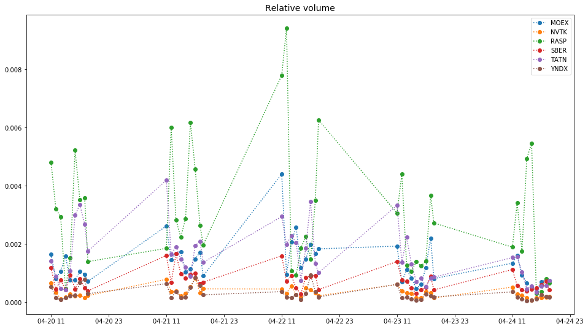

```python
plt.title('Relative volume',fontdict={'size':14})
for col in df_relative_volume:
    plt.plot(col, data=df_relative_volume, ls=':', marker='o', label=col);
plt.legend();
```

Можно посмотреть на распределение значений, представленных в таблице, в разрезе компаний. Однако так теряется информация о динамике показателя. Ниже представлен график

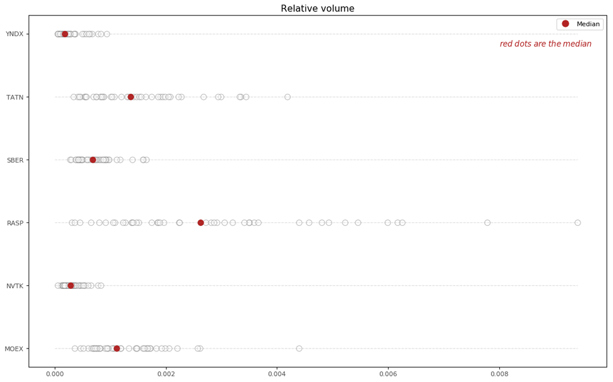

```python
fig, ax = plt.subplots(figsize=(16,10), dpi= 80)
ax.hlines(y=df_relative_volume.columns, xmin=0, xmax=df_relative_volume.max().max(), color='gray', alpha=0.5, linewidth=0.5, linestyles='dashdot')

for i, col in enumerate(df_relative_volume):
    ax.scatter(y=i*np.ones(len(df_relative_volume)), x=col, data=df_relative_volume, s=75, edgecolors='gray', c='w', alpha=0.5)
    ax.scatter(y=i, x=df_relative_volume[col].median(), s=75, c='firebrick')

ax.text(0.85*df_relative_volume.max().max(), 4.8, "$red \; dots \; are \; the \: median$", fontdict={'size':12}, color='firebrick')
red_patch = plt.plot([],[], marker="o", ms=10, ls="", mec=None, color='firebrick', label="Median")
plt.legend(handles=red_patch)
ax.set_title('Relative volume', fontdict={'size':14})
plt.xticks(alpha=0.7)
plt.yticks(alpha=0.7)
plt.show()
```

```python
df_relative_value.head()
```

|  | MOEX | NVTK | RASP | SBER | TATN | YNDX |
| --- | --- | --- | --- | --- | --- | --- |
| 2020-04-20 11:00:00 | 0.001631 | 0.000646 | 0.004814 | 0.001176 | 0.001404 | 0.000519 |
| 2020-04-20 12:00:00 | 0.000802 | 0.000337 | 0.003207 | 0.000432 | 0.000874 | 0.000145 |
| 2020-04-20 13:00:00 | 0.001059 | 0.000112 | 0.002919 | 0.000765 | 0.000462 | 0.000075 |
| 2020-04-20 14:00:00 | 0.001582 | 0.000164 | 0.000454 | 0.000425 | 0.000415 | 0.000144 |
| 2020-04-20 15:00:00 | 0.000747 | 0.000275 | 0.001510 | 0.000918 | 0.001071 | 0.000207 |

Выше приведена таблица первых нескольких значений "относительного объема торгов в деньгах" для выбранных акций. Например значение 0.001631 (первая строка первый столбец) означает, что за первый час торгов 2020-04-20 обернулось 0.1631% стоимости акций Московской биржи от суммарной капитализации, посчитанной по всем акциям, находящимся в свободном обращении. Видно, что у всех компаний значения данного показателя очень близки с значениями из предыдущей таблицы. Если посмотреть на формулы, то становится понятно, что "относительный объем торгов в деньгах" - это фактически взвешенный по ценам "относительный объем торгов в штуках". Предположительно, данные коэффициенты будут сильно различаться, если колебания цены внутри периода были сильные (иначе говоря была сильная волатильность цен)

Визуализируем данную таблицу в вде графика изменения показателя в динамике

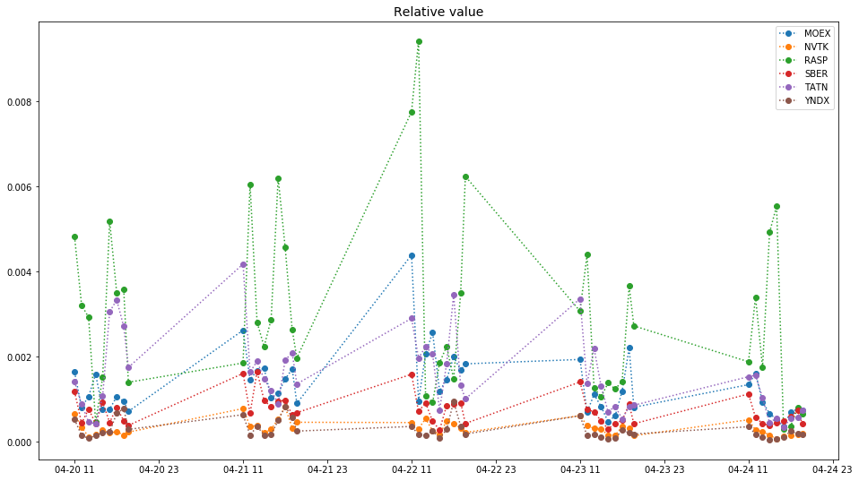

```python
plt.title('Relative value',fontdict={'size':14})
for col in df_relative_value:
    plt.plot(col, data=df_relative_value, ls=':', marker='o', label=col);
plt.legend();
```

А так же снова посмотрим на распределение показателя в разрезе компаний

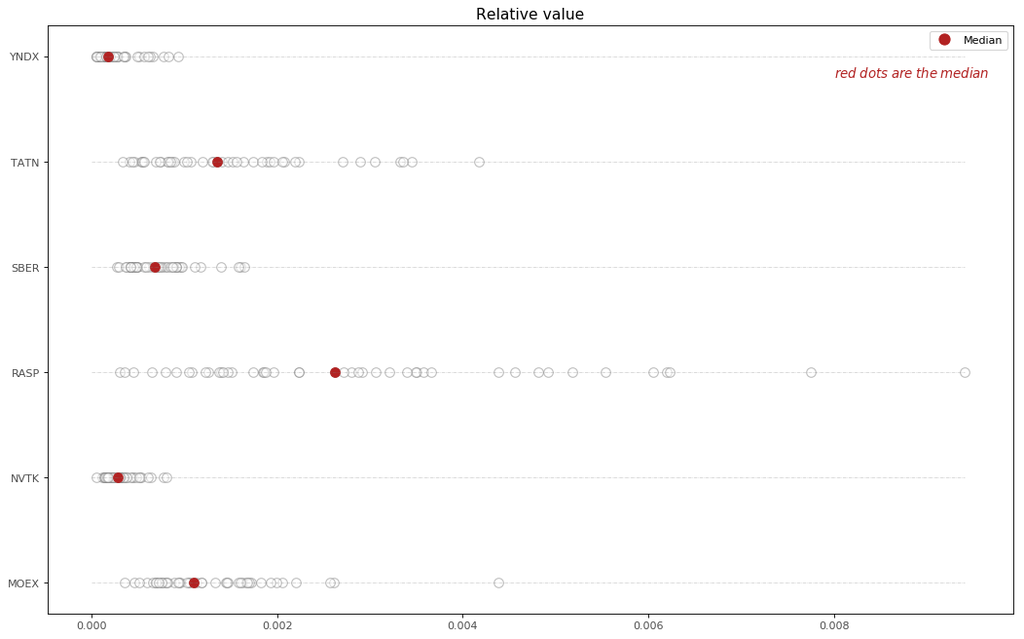

```python
fig, ax = plt.subplots(figsize=(16,10), dpi= 80)
ax.hlines(y=df_relative_value.columns, xmin=0, xmax=df_relative_value.max().max(), color='gray', alpha=0.5, linewidth=0.5, linestyles='dashdot')

for i, col in enumerate(df_relative_value):
    ax.scatter(y=i*np.ones(len(df_relative_value)), x=col, data=df_relative_value, s=75, edgecolors='gray', c='w', alpha=0.5)
    ax.scatter(y=i, x=df_relative_value[col].median(), s=75, c='firebrick')

ax.text(0.85*df_relative_value.max().max(), 4.8, "$red \; dots \; are \; the \: median$", fontdict={'size':12}, color='firebrick')
red_patch = plt.plot([],[], marker="o", ms=10, ls="", mec=None, color='firebrick', label="Median")
plt.legend(handles=red_patch)
ax.set_title('Relative value', fontdict={'size':14})
plt.xticks(alpha=0.7)
plt.yticks(alpha=0.7)
plt.show()
```

Стоит заметить, что на двух графиках выше видно, как у большинства компаний в показателях явно выражены два пика в начале и в конце торгового дня. Видимо, торговая активность, а вместе с тем и ликвидность, выше утром и вечером.

Посмотрим на "количество совершенных сделок"

```python
df_deals_count.head()
```

|  | MOEX | NVTK | RASP | SBER | TATN | YNDX |
| --- | --- | --- | --- | --- | --- | --- |
| 2020-04-20 11:00:00 | 6092 | 4147 | 800 | 15780 | 5851 | 5685 |
| 2020-04-20 12:00:00 | 2586 | 2873 | 692 | 7042 | 5291 | 2136 |
| 2020-04-20 13:00:00 | 2558 | 1103 | 701 | 10351 | 3093 | 1239 |
| 2020-04-20 14:00:00 | 3610 | 1510 | 98 | 7758 | 2989 | 2212 |
| 2020-04-20 15:00:00 | 2236 | 2014 | 217 | 13073 | 6300 | 2261 |

Опять же визуализируем данную таблицу, построив изменение показателя в динамике и распределение показателя в разрезе компаний

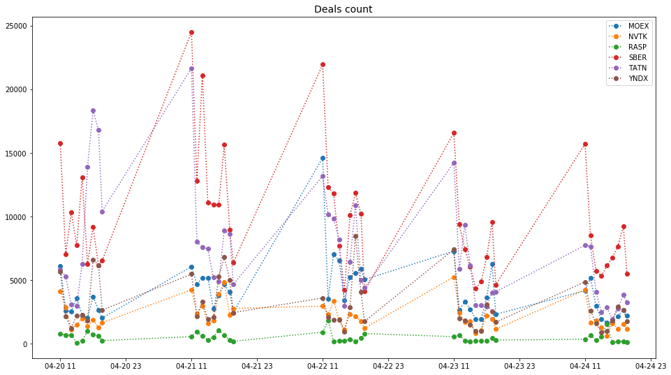

```python
plt.title('Deals count',fontdict={'size':14})
for col in df_deals_count:
    plt.plot(col, data=df_deals_count, ls=':', marker='o', label=col);
plt.legend();
```

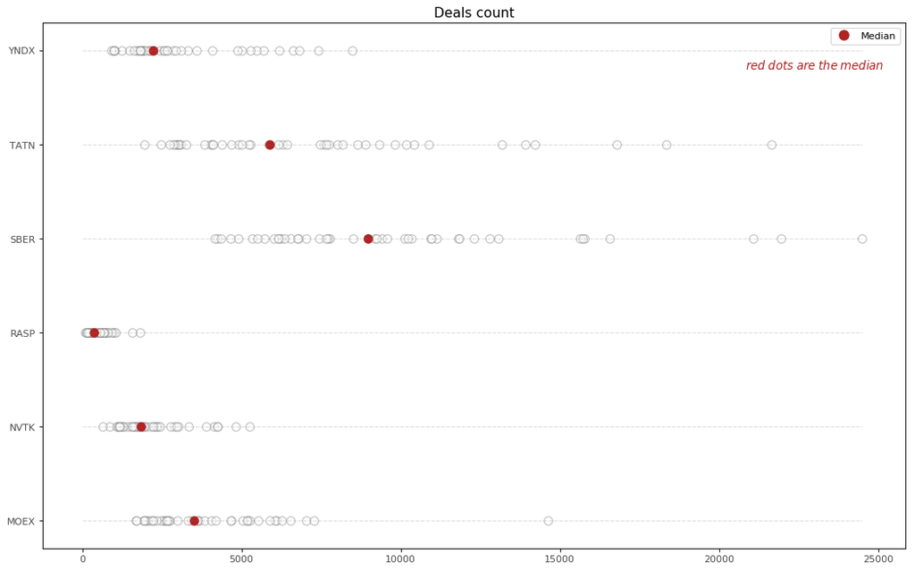

```python
fig, ax = plt.subplots(figsize=(16,10), dpi= 80)
ax.hlines(y=df_deals_count.columns, xmin=0, xmax=df_deals_count.max().max(), color='gray', alpha=0.5, linewidth=0.5, linestyles='dashdot')

for i, col in enumerate(df_deals_count):
    ax.scatter(y=i*np.ones(len(df_deals_count)), x=col, data=df_deals_count, s=75, edgecolors='gray', c='w', alpha=0.5)
    ax.scatter(y=i, x=df_deals_count[col].median(), s=75, c='firebrick')

ax.text(0.85*df_deals_count.max().max(), 4.8, "$red \; dots \; are \; the \: median$", fontdict={'size':12}, color='firebrick')
red_patch = plt.plot([],[], marker="o", ms=10, ls="", mec=None, color='firebrick', label="Median")
plt.legend(handles=red_patch)
ax.set_title('Deals count', fontdict={'size':14})
plt.xticks(alpha=0.7)
plt.yticks(alpha=0.7)
plt.show()
```

Интересно посмотреть на суммарное количество сделок за всю неделю торгов

```python
df_deals_count.sum()
```

```
MOEX    180004
NVTK     97490
RASP     22803
SBER    439185
TATN    320517
YNDX    135337
dtype: int64
```

Опять же можно заметить, что у данного показателя визуально опять присутствуют пики в начале и в конце торгового дня.

Теперь посмотрим на среднее время ожидания между сделками (в секундах)

```python
df_deals_timeout.head()
```

|  | MOEX | NVTK | RASP | SBER | TATN | YNDX |
| --- | --- | --- | --- | --- | --- | --- |
| 2020-04-20 11:00:00 | 0.590708 | 0.868082 | 4.466119 | 0.228136 | 0.615220 | 0.633110 |
| 2020-04-20 12:00:00 | 1.392020 | 1.246578 | 5.199602 | 0.511141 | 0.679696 | 1.684912 |
| 2020-04-20 13:00:00 | 1.406786 | 3.275420 | 5.058201 | 0.347698 | 1.164613 | 2.901104 |
| 2020-04-20 14:00:00 | 0.996872 | 2.383191 | 36.647424 | 0.464064 | 1.201529 | 1.626031 |
| 2020-04-20 15:00:00 | 1.604552 | 1.785669 | 16.494564 | 0.275321 | 0.572368 | 1.591450 |

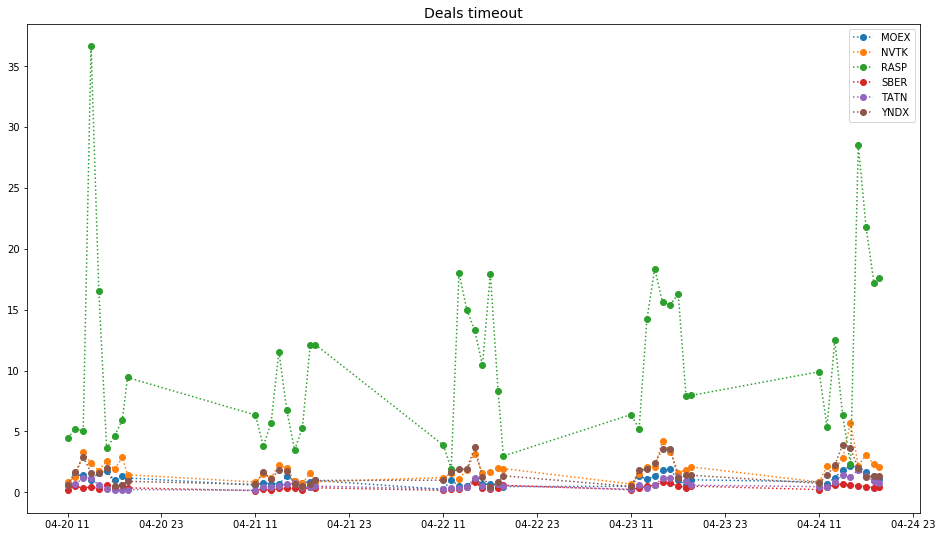

```python
plt.title('Deals timeout',fontdict={'size':14})
for col in df_deals_timeout:
    plt.plot(col, data=df_deals_timeout, ls=':', marker='o', label=col);
plt.legend();
```

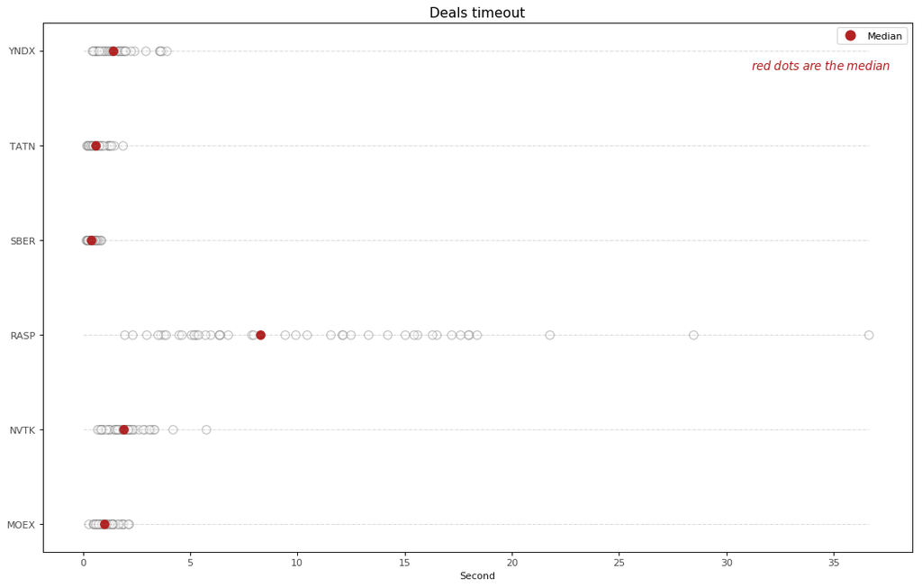

```python
fig, ax = plt.subplots(figsize=(16,10), dpi= 80)
ax.hlines(y=df_deals_timeout.columns, xmin=0, xmax=df_deals_timeout.max().max(), color='gray', alpha=0.5, linewidth=0.5, linestyles='dashdot')

for i, col in enumerate(df_deals_timeout):
    ax.scatter(y=i*np.ones(len(df_deals_timeout)), x=col, data=df_deals_timeout, s=75, edgecolors='gray', c='w', alpha=0.5)
    ax.scatter(y=i, x=df_deals_timeout[col].median(), s=75, c='firebrick')

ax.text(0.85*df_deals_timeout.max().max(), 4.8, "$red \; dots \; are \; the \: median$", fontdict={'size':12}, color='firebrick')
red_patch = plt.plot([],[], marker="o", ms=10, ls="", mec=None, color='firebrick', label="Median")
plt.legend(handles=red_patch)
ax.set_title('Deals timeout', fontdict={'size':14})
ax.set_xlabel('Second', alpha=0.9)
plt.xticks(alpha=0.7)
plt.yticks(alpha=0.7)
plt.show()
```

Из-за сильного разброса значений показателя у компании RASP, значения показателя других компаний сливаются между собой, поэтому рассмотрим отдельно график распределения показателя без данной компании

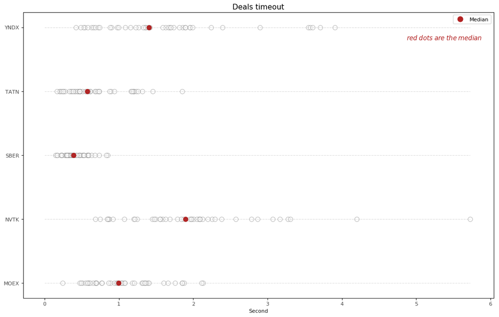

```python
cols = ['MOEX', 'NVTK', 'SBER', 'TATN', 'YNDX']
df_temp = df_deals_timeout[cols]

fig, ax = plt.subplots(figsize=(16,10), dpi= 80)
ax.hlines(y=df_temp.columns, xmin=0, xmax=df_temp.max().max(), color='gray', alpha=0.5, linewidth=0.5, linestyles='dashdot')

for i, col in enumerate(df_temp):
    ax.scatter(y=i*np.ones(len(df_temp)), x=col, data=df_temp, s=75, edgecolors='gray', c='w', alpha=0.5)
    ax.scatter(y=i, x=df_temp[col].median(), s=75, c='firebrick')

ax.text(0.85*df_temp.max().max(), 3.8, "$red \; dots \; are \; the \: median$", fontdict={'size':12}, color='firebrick')
red_patch = plt.plot([],[], marker="o", ms=10, ls="", mec=None, color='firebrick', label="Median")
plt.legend(handles=red_patch)
ax.set_title('Deals timeout', fontdict={'size':14})
ax.set_xlabel('Second', alpha=0.9)
plt.xticks(alpha=0.7)
plt.yticks(alpha=0.7)
plt.show()
```

И посмотрим на среднее значение данного показателя за неделю

```python
df_deals_timeout.mean()
```

```
MOEX     1.071873
NVTK     1.972861
RASP    10.644982
SBER     0.423009
TATN     0.678381
YNDX     1.599569
dtype: float64
```

У данного показателя уже нет явно выраженных пиков в начале и в конце торгового дня, за то по нему можно однозначно отделить акции компании RASP от всех остальных

Следующий показатель, который мы рассмотрим - это относительный спред. У данного показателя нет особого физического смысла. Он меньше для тех акций, у которых меньше абсолютный спред (это числитель) и/или больше цена самой акции (это знаменатель). Данный показатель будет равен в случаях, когда спред равен 2 рублям, а цена (средняя точка) примерно равна 10 рублям и когда спред равен 20 рублям, а цена (средняя точка) примерно равна 100 рублям. Однако это немного неадекватное сравнение. Более того, числитель при таком рассчете всегда технически ограничен снизу (он не может быть меньше шага цены), из-за чего опять же могут возникнуть некорректные сравнения в разрезе различных компаний.

```python
df_relative_spread.head()
```

|  | MOEX | NVTK | RASP | SBER | TATN | YNDX |
| --- | --- | --- | --- | --- | --- | --- |
| 2020-04-20 11:00:00 | 0.000411 | 0.000551 | 0.001493 | 0.000295 | 0.000629 | 0.000526 |
| 2020-04-20 12:00:00 | 0.000223 | 0.000504 | 0.001013 | 0.000231 | 0.000444 | 0.000438 |
| 2020-04-20 13:00:00 | 0.000275 | 0.000488 | 0.000984 | 0.000216 | 0.000395 | 0.000386 |
| 2020-04-20 14:00:00 | 0.000211 | 0.000618 | 0.000970 | 0.000208 | 0.000472 | 0.000448 |
| 2020-04-20 15:00:00 | 0.000218 | 0.000588 | 0.001367 | 0.000204 | 0.000389 | 0.000423 |

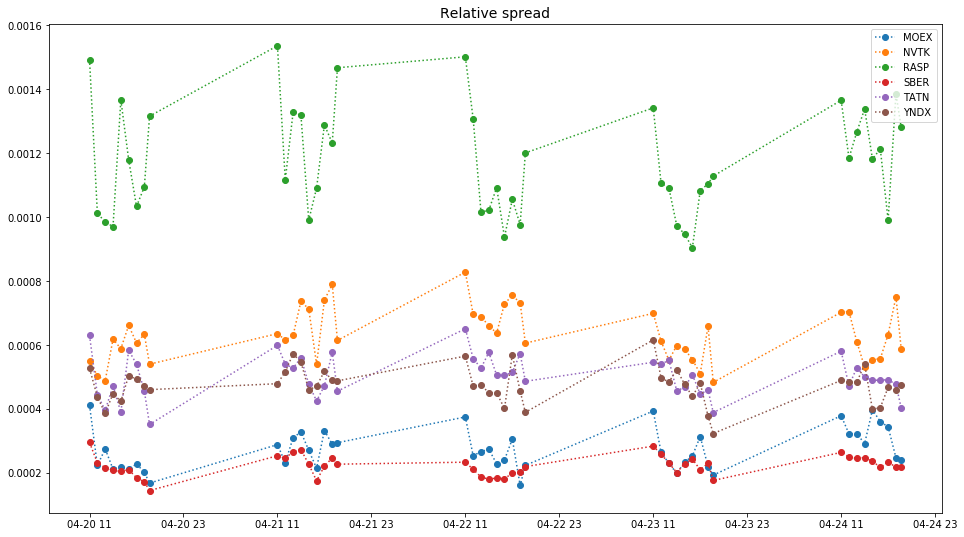

```python
plt.title('Relative spread',fontdict={'size':14})
for col in df_relative_spread:
    plt.plot(col, data=df_relative_spread, ls=':', marker='o', label=col);
plt.legend(loc='upper right');
```

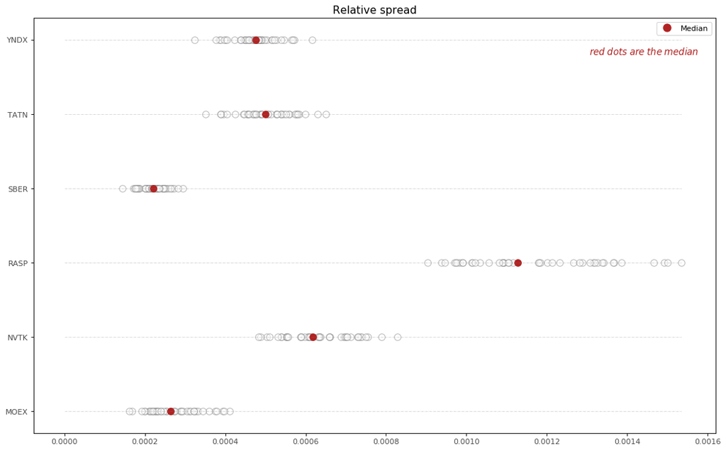

```python
fig, ax = plt.subplots(figsize=(16,10), dpi= 80)
ax.hlines(y=df_relative_spread.columns, xmin=0, xmax=df_relative_spread.max().max(), color='gray', alpha=0.5, linewidth=0.5, linestyles='dashdot')

for i, col in enumerate(df_relative_spread):
    ax.scatter(y=i*np.ones(len(df_relative_spread)), x=col, data=df_relative_spread, s=75, edgecolors='gray', c='w', alpha=0.5)
    ax.scatter(y=i, x=df_relative_spread[col].median(), s=75, c='firebrick')

ax.text(0.85*df_relative_spread.max().max(), 4.8, "$red \; dots \; are \; the \: median$", fontdict={'size':12}, color='firebrick')
red_patch = plt.plot([],[], marker="o", ms=10, ls="", mec=None, color='firebrick', label="Median")
plt.legend(handles=red_patch)
ax.set_title('Relative spread', fontdict={'size':14})
plt.xticks(alpha=0.7)
plt.yticks(alpha=0.7)
plt.show()
```

Следующий показатель - LOGQS. Он опять же не имееят особого физического смысла. Он меньше для тех акций, у кого меньше спред (числитель) и/или больше широта рынка (знаменатель). Логарифм обеспечивает возможность сравнения данного показателя в разрезе компаний т.к. придает смысле относительных приращений

```python
df_LOGQS.head()
```

|  | MOEX | NVTK | RASP | SBER | TATN | YNDX |
| --- | --- | --- | --- | --- | --- | --- |
| 2020-04-20 11:00:00 | 0.000033 | 0.000056 | 0.000150 | 0.000021 | 0.000059 | 0.000101 |
| 2020-04-20 12:00:00 | 0.000017 | 0.000051 | 0.000093 | 0.000016 | 0.000040 | 0.000091 |
| 2020-04-20 13:00:00 | 0.000022 | 0.000047 | 0.000095 | 0.000015 | 0.000033 | 0.000089 |
| 2020-04-20 14:00:00 | 0.000016 | 0.000061 | 0.000104 | 0.000014 | 0.000041 | 0.000085 |
| 2020-04-20 15:00:00 | 0.000016 | 0.000052 | 0.000138 | 0.000014 | 0.000034 | 0.000076 |

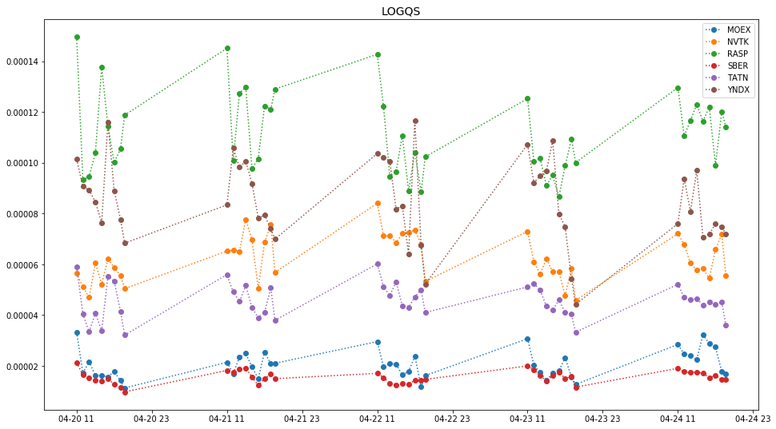

```python
plt.title('LOGQS',fontdict={'size':14})
for col in df_LOGQS:
    plt.plot(col, data=df_LOGQS, ls=':', marker='o', label=col);
plt.legend();
```

[figure not shown]

```python
fig, ax = plt.subplots(figsize=(16,10), dpi= 80)
ax.hlines(y=df_LOGQS.columns, xmin=0, xmax=df_LOGQS.max().max(), color='gray', alpha=0.5, linewidth=0.5, linestyles='dashdot')

for i, col in enumerate(df_LOGQS):
    ax.scatter(y=i*np.ones(len(df_LOGQS)), x=col, data=df_LOGQS, s=75, edgecolors='gray', c='w', alpha=0.5)
    ax.scatter(y=i, x=df_LOGQS[col].median(), s=75, c='firebrick')

ax.text(0.85*df_LOGQS.max().max(), 4.8, "$red \; dots \; are \; the \: median$", fontdict={'size':12}, color='firebrick')
red_patch = plt.plot([],[], marker="o", ms=10, ls="", mec=None, color='firebrick', label="Median")
plt.legend(handles=red_patch)
ax.set_title('Relative spread', fontdict={'size':14})
plt.xticks(alpha=0.7)
plt.yticks(alpha=0.7)
plt.show()
```

## Ранжирование

Компании, выбранные для анализа, тяжело явно разделить на какие-то группы ликвидности. Более того, все они включены в индекс МосБиржы, одним из критериев включения в который как раз является прохождения некоторого порога ликвидности, посчитанной по методике биржы, поэтому все они высоколиквидные.

Однако, визуально рассмотрев распределения различных показателей для данных компаний, в глаза бросается тот факт, что акции SBER практически всегда показывают наилучший результат, тогда как акции RASP - наихудший. Случаи, когда это не так, у показателей "относительный объем торгов в штуках" и "относительный объем торгов в деньгах" (а как мы помним, это практически один и тот же показатель). Если бы не этот показатель, то рассматриваемые акции явно можно было бы поделить на несколько групп, причем сделать это следующим формальным способом

Отсортируем медианное значения показателя ликвидности от наилучшего к наихудшему и сделаем это для каждого типа показателя. Таким образом возникает отношение порядка на множестве выбранных компаний. Пересечение полученных отношений порядка даст нам частично упорядоченное множество (пример - рисунок ниже). Тогда все элементы, находящиеся на одном уровне, можно отнести к одной группе. Такой подход слабо применим в случае, когда множество анализируемых элементов большое, потому что граф сильно разрастается и в нем тяжело (а иногда и практически невозможно) явно выделить какие-либо группы, но в нашем случае получается красивый результат.

[figure not shown]

```python
df_deals_count.median().sort_values(ascending=False)
```

```
SBER    8967.0
TATN    5889.0
MOEX    3509.0
YNDX    2212.0
NVTK    1830.0
RASP     358.0
dtype: float64
```

```python
df_deals_timeout.median().sort_values(ascending=True)
```

```
SBER    0.388952
TATN    0.572368
MOEX    0.996872
YNDX    1.404281
NVTK    1.894430
RASP    8.284936
dtype: float64
```

```python
df_relative_spread.median().sort_values(ascending=True)
```

```
SBER    0.000221
MOEX    0.000264
YNDX    0.000476
TATN    0.000499
NVTK    0.000618
RASP    0.001128
dtype: float64
```

```python
df_LOGQS.median().sort_values(ascending=True)
```

```
SBER    0.000015
MOEX    0.000020
TATN    0.000045
NVTK    0.000061
YNDX    0.000083
RASP    0.000110
dtype: float64
```

Таким образом мы получаем, что акции SBER можно отнести к наиболее ликвидным, акции RASP - к наименее ликвидным, а все остальные - к среднней ликвидности. Возможно, из-за хорошей надежности компании и ее фундаментальных показателей проходит большой объем торгов акциями RASP, а из-за маленького коэффициента free-float, коэффициенты "относительный объем торгов в штуках" и "относительный объем торгов в деньгах" показывают хорошие значения ликвидности - лучше, чем у SBER и остальных